# Practical Machine Learning Course Project

Yuhua Zhang

Friday, July 17, 2015

## Introduction

Using devices such as Jawbone Up, Nike FuelBand, and Fitbit it is now possible to collect a large amount of data about personal activity relatively inexpensively. These type of devices are part of the quantified self movement - a group of enthusiasts who take measurements about themselves regularly to improve their health, to find patterns in their behavior, or because they are tech geeks. One thing that people regularly do is quantify how much of a particular activity they do, but they rarely quantify how well they do it. In this project, the project will be to use data from accelerometers on the belt, forearm, arm, and dumbell of 6 participants. They were asked to perform barbell lifts correctly and incorrectly in 5 different ways.

## Data

The training data for this project are available here:

https://d396qusza40orc.cloudfront.net/predmachlearn/pml-training.csv

The test data are available here:

https://d396qusza40orc.cloudfront.net/predmachlearn/pml-testing.csv

The data for this project come from this source: http://groupware.les.inf.puc-rio.br/har. If you use the document you create for this class for any purpose please cite them as they have been very generous in allowing their data to be used for this kind of assignment.

## Load and clean the data

```r
trainUrl <- "https://d396qusza40orc.cloudfront.net/predmachlearn/pml-training.csv"
testUrl <- "https://d396qusza40orc.cloudfront.net/predmachlearn/pml-testing.csv"
trainda <- read.csv(url(trainUrl), na.strings=c("NA","#DIV/0!",""))
testda <- read.csv(url(testUrl), na.strings=c("NA","#DIV/0!",""))
# Remove columns with more than 95% of "NA" or ""
library(caret)
training <- trainda[, 6:dim(trainda)[2]]
treshold <- dim(training)[1] * 0.95
goodCol <- !apply(training, 2, function(x) sum(is.na(x)) > treshold  || sum(x=="") > treshold)
training <- training[, goodCol]
badCol <- nearZeroVar(training, saveMetrics = TRUE)
training <- training[, badCol$nzv==FALSE]
training$classe = factor(training$classe)
```

## Partition training dataset

Part the training set into two data sets, 60% mytraining and 40% mytesting respectively.

```r
intrain <- createDataPartition(y=trainda$classe, p=0.6, list=FALSE)
mytrain <- training[intrain, ]
mytest <- training[-intrain, ]
dim(mytrain)
```

```
## [1] 11776    54
```

```r
dim(mytest)
```

```
## [1] 7846   54
```

## Prediction

To make prediction,I will use decision tree and random forest algorithms. The algorithm with the highest accuracy will be chosen as final model. Cross-validation will be performed by subsampling our training data set randomly without replacement into 2 subsamples: mytraining data and myTesting data.Models will be fitted on mytraing dataset, and tested on mytesting dataset. The most accurate model fitted will be tested on the original Testing data set.

### Decision trees for prediction

```r
library(rpart)
```

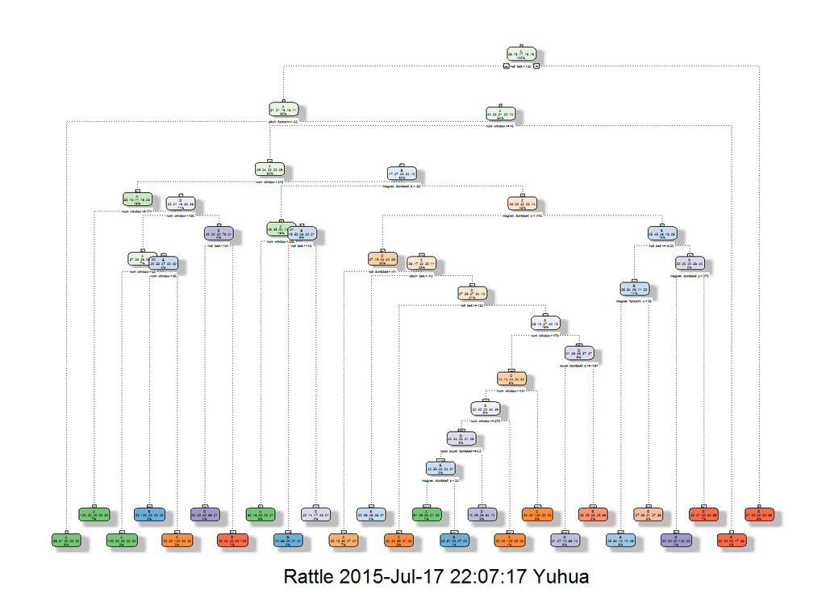

```r
library(rpart.plot)
library(RColorBrewer)
library(rattle)
model1 <- rpart(classe ~ ., data=mytrain, method="class")
fancyRpartPlot(model1)
```

```r
# Predict
pred1 <- predict(model1, mytest, type = "class")
# Use confusion matrix to test results
confusionMatrix(pred1, mytest$classe)
```

```
## Confusion Matrix and Statistics
##
##           Reference
## Prediction    A    B    C    D    E
##          A 1935  128    2   16    6
##          B  150 1139  105  108   56
##          C    1   75 1102   51    4
##          D  124   92  147  978   96
##          E   22   84   12  133 1280
##
## Overall Statistics
##
##                Accuracy : 0.82
##                  95% CI : (0.8114, 0.8285)
##     No Information Rate : 0.2845
##     P-Value [Acc > NIR] : < 2.2e-16
##
##                   Kappa : 0.773
##  Mcnemar's Test P-Value : < 2.2e-16
##
## Statistics by Class:
##
##                      Class: A Class: B Class: C Class: D Class: E
## Sensitivity            0.8669   0.7503   0.8056   0.7605   0.8877
## Specificity            0.9729   0.9338   0.9798   0.9300   0.9608
## Pos Pred Value         0.9272   0.7311   0.8938   0.6806   0.8361
## Neg Pred Value         0.9484   0.9397   0.9598   0.9519   0.9743
## Prevalence             0.2845   0.1935   0.1744   0.1639   0.1838
## Detection Rate         0.2466   0.1452   0.1405   0.1246   0.1631
## Detection Prevalence   0.2660   0.1986   0.1572   0.1832   0.1951
## Balanced Accuracy      0.9199   0.8421   0.8927   0.8453   0.9242
```

### Random forest for prediction

```r
library(randomForest)
model2 <- randomForest(classe ~. , data=mytrain)
# Predict
pred2 <- predict(model2, mytest, type = "class")
# Use confusion matrix to test results
confusionMatrix(pred2, mytest$classe)
```

```
## Confusion Matrix and Statistics
##
##           Reference
## Prediction    A    B    C    D    E
##          A 2231    5    0    0    0
##          B    0 1510   13    0    0
##          C    0    3 1355   13    0
##          D    0    0    0 1272    4
##          E    1    0    0    1 1438
##
## Overall Statistics
##
##                Accuracy : 0.9949
##                  95% CI : (0.9931, 0.9964)
##     No Information Rate : 0.2845
##     P-Value [Acc > NIR] : < 2.2e-16
##
##                   Kappa : 0.9936
##  Mcnemar's Test P-Value : NA
##
## Statistics by Class:
##
##                      Class: A Class: B Class: C Class: D Class: E
## Sensitivity            0.9996   0.9947   0.9905   0.9891   0.9972
## Specificity            0.9991   0.9979   0.9975   0.9994   0.9997
## Pos Pred Value         0.9978   0.9915   0.9883   0.9969   0.9986
## Neg Pred Value         0.9998   0.9987   0.9980   0.9979   0.9994
## Prevalence             0.2845   0.1935   0.1744   0.1639   0.1838
## Detection Rate         0.2843   0.1925   0.1727   0.1621   0.1833
## Detection Prevalence   0.2850   0.1941   0.1747   0.1626   0.1835
## Balanced Accuracy      0.9993   0.9963   0.9940   0.9943   0.9985
```

## Submission

```r
# Function to submit assignment
pml_write_files = function(x){
  n = length(x)
  for(i in 1:n){
    filename = paste0("problem_id_",i,".txt")
    write.table(x[i],file=filename,quote=FALSE,row.names=FALSE,col.names=FALSE)
  }
}
# Use random forest on testing dataset
answers <- predict(model2, testda, type = "class")
answers
```

```
##  1  2  3  4  5  6  7  8  9 10 11 12 13 14 15 16 17 18 19 20
##  B  A  B  A  A  E  D  B  A  A  B  C  B  A  E  E  A  B  B  B
## Levels: A B C D E
```

```r
pml_write_files(answers)
```